# Markdown cheatsheet

Katriona Goldmann

2020-07-24

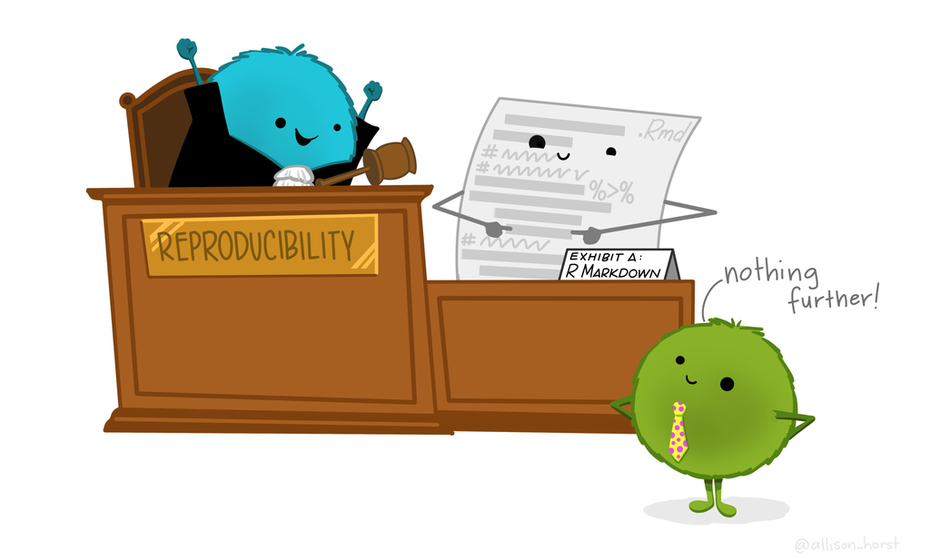

Image by Allison Horst (@allison_horst)

This is a document outlining my favourite markdownd set-ups and common implementations.

# Quick-start

Some chunk parameters to bear in mind:

| Parameter | Values | Purpose |
| --- | --- | --- |
| eval | TRUE | Whether to evaluate the code and include its results |
| echo | TRUE | Whether to display code along with its results |
| warning | TRUE | Whether to display warnings |
| error | FALSE | Whether to display errors |
| message | TRUE | Whether to display messages |
| tidy | FALSE | Whether to reformat code in a tidy way when displaying it |
| results | “markup” “markup”, “asis”, “hold”, or “hide” | How to ouput the results |
| cache | FALSE | Whether to cache results for future renders |
| comment | “##” | Comment character to preface results with |
| fig.width | 7 | Width in inches for plots created in chunk |
| fig.height | 7 | Height in inches for plots created in chunk |

# Set up the Document

The document is set up using the YAML (a recursive acronym for “YAML Ain’t Markup Language”): a human-readable data-serialization language which goes right at the start. It is used for configuring the file so useful for TOC, titles, authorship and dates.

## Using Today’s Date

date:

```r
"`r format(Sys.time(), '%d %B, %Y')`"
```

To use this by default in the document add this line to the YAML:

```markdown
---
title: "Markdown cheatsheet"
date: "`r Sys.Date()`"
---
```

## Including a contents page

In the YAML include

```
---
title: "Markdown cheatsheet"
 html_document:
  toc: yes
---
```

### Floating TOC at LHS

```
---
title: "Markdown cheatsheet"
output:
  html_document:
    toc: true
    toc_float: true
---
```

### Collapsible TOC

```
---
title: "Markdown cheatsheet"
output:
  html_document:
    toc: true
    toc_float:
      collapsed: false
---
```

### TOC at the start

```r
source("https://gist.githubusercontent.com/KatrionaGoldmann/3d6dfd6aa4cc5c3940bb72dc49beae02/raw/26e78c78a7a9d096d695c708e8a45830a1d1121a/render_toc.R")
render_toc("./Extended_Vignette.rmd")
```

### Including a TOC sidebar

As is used here on the left hand side

In the YAML:

```
---
output:
 html_document:
  css: cheatsheet.css
  toc: yes
---
```

Call on the css styling saves to cheatsheet.css or within the markdown:

```
<style>
#TOC {
  position: fixed;
  left: 0;
  top: 0;
  width: 250px;
  background-color: #B7E1F1;
  height: 100%;
  overflow:auto;
}
body {
  max-width: 800px;
  margin: auto;
  margin-left:260px;
  line-height: 20px;
 }
 </style>
```

### Hide Header from TOC

Add {.toc-ignore}

```
# Hidden header {.toc-ignore}
```

## Adding a favicon

Add an image to the header of the document. To change the icon (from heart) change to url to point to another icon:

```r
fileConn <- file("myheader.html")
writeLines('<link rel="shortcut icon" href="http://d1ujqdpfgkvqfi.cloudfront.net/favicon-generator/htdocs/favicons/2013-10-15/19fefe8ca2a66ba90e35d0d5fc7162a6.ico">', fileConn)
close(fileConn)
```

# Document Transparency

This will let you copy plots across wihout the white background etc.

```r
knitr::opts_chunk$set(dev.args=list(bg="transparent"))
```

# Code-Folding

Code-folding is really useful to allow readers to inspect code if they wish but without cluttering up the document. For example:

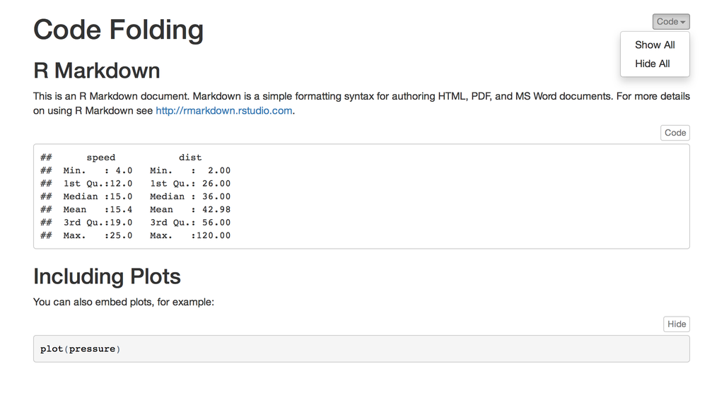

To do this add code_folding to your YAML:

```
---
output:
 html_document:
  code_folding: hide
---
```

# Tabbing Content

For This converts subsections to tabs. example

## Start tabbing section

### tab 1

tab content 1

### tab 2

tab content 2

code:

```
## Start tabbing section {.toc-ignore .tabset .tabset-fade}
content above tabbed region.

### tab 1 {.toc-ignore}

tab content 1

### tab 2 {.toc-ignore}

tab content 2

##
```

To include in the toc, simply remove the .toc-ignore. Doing it natively in R, in a loop:

```
``{r, results='asis'}
for(i in paste('tab', 1:2)){
  cat('\n')
  cat('###', i, '\n')
  cat('analysis for var', i)
  cat('\n')
}
``
```

# Shiny Apps

To include shiny apps you will need to add to your yaml:

```
---
title: "A Shiny Enabled Document"
output: html_document
runtime: shiny
---
```

```r
selectInput(
  'breaks', label = 'Number of bins:',
  choices = c(10, 20, 35, 50), selected = 20
)

renderPlot({
  par(mar = c(4, 4, .1, .5))
  hist(
    faithful$eruptions, as.numeric(input$breaks),
    col = 'gray', border = 'white',
    xlab = 'Duration (minutes)', main = ''
  )
})
```

# Highlight section

To highlight a section you can create a div:

```
<style>
div.blue { background-color:#e6f0ff; border-radius: 5px; padding: 20px;}
</style>

<div class = "blue">
Let try highlighting this phrase
</div>
```

Let try highlighting this phrase

To highlight only words:

```
<span style="background-color: lightgrey; border-radius: 5px; padding: 2px">R</span>; <span style="background-color: lightgrey; border-radius: 5px; padding: 2px">data visualisation</span>; <span style="background-color: lightgrey; border-radius: 5px; padding: 2px">bioinformatics</span>; <span style="background-color: lightgrey; border-radius: 5px; padding: 2px">transcriptomics</span>;
```

R; data visualisation; bioinformatics; transcriptomics;

# Data Tables

## Scrollable tables

```r
library("kableExtra")
kable(iris)  %>%
  kable_styling() %>%
  scroll_box(width = "100%", height = "200px")
```

| Sepal.Length | Sepal.Width | Petal.Length | Petal.Width | Species |
| --- | --- | --- | --- | --- |
| 5.1 | 3.5 | 1.4 | 0.2 | setosa |
| 4.9 | 3.0 | 1.4 | 0.2 | setosa |
| 4.7 | 3.2 | 1.3 | 0.2 | setosa |
| 4.6 | 3.1 | 1.5 | 0.2 | setosa |
| 5.0 | 3.6 | 1.4 | 0.2 | setosa |
| 5.4 | 3.9 | 1.7 | 0.4 | setosa |
| 4.6 | 3.4 | 1.4 | 0.3 | setosa |
| 5.0 | 3.4 | 1.5 | 0.2 | setosa |
| 4.4 | 2.9 | 1.4 | 0.2 | setosa |
| 4.9 | 3.1 | 1.5 | 0.1 | setosa |
| 5.4 | 3.7 | 1.5 | 0.2 | setosa |
| 4.8 | 3.4 | 1.6 | 0.2 | setosa |
| 4.8 | 3.0 | 1.4 | 0.1 | setosa |
| 4.3 | 3.0 | 1.1 | 0.1 | setosa |
| 5.8 | 4.0 | 1.2 | 0.2 | setosa |
| 5.7 | 4.4 | 1.5 | 0.4 | setosa |
| 5.4 | 3.9 | 1.3 | 0.4 | setosa |
| 5.1 | 3.5 | 1.4 | 0.3 | setosa |
| 5.7 | 3.8 | 1.7 | 0.3 | setosa |
| 5.1 | 3.8 | 1.5 | 0.3 | setosa |
| 5.4 | 3.4 | 1.7 | 0.2 | setosa |
| 5.1 | 3.7 | 1.5 | 0.4 | setosa |
| 4.6 | 3.6 | 1.0 | 0.2 | setosa |
| 5.1 | 3.3 | 1.7 | 0.5 | setosa |
| 4.8 | 3.4 | 1.9 | 0.2 | setosa |
| 5.0 | 3.0 | 1.6 | 0.2 | setosa |
| 5.0 | 3.4 | 1.6 | 0.4 | setosa |
| 5.2 | 3.5 | 1.5 | 0.2 | setosa |
| 5.2 | 3.4 | 1.4 | 0.2 | setosa |
| 4.7 | 3.2 | 1.6 | 0.2 | setosa |

[output cut: 120 more lines]

## Downloadable DT tables

```r
library("DT")
DT::datatable(iris, extensions = 'Buttons',
                options=list(dom = 'Bfrtip',
                             buttons = c('excel','csv','print'),
                             rowCallback=JS(
                               'function(row,data) {
     if($(row)["0"]["_DT_RowIndex"] % 2 <1)
            $(row).css("background","#f2f9ec")
    }')))
```

|  | Sepal.Length | Sepal.Width | Petal.Length | Petal.Width | Species |
| --- | --- | --- | --- | --- | --- |
| 1 | 5.1 | 3.5 | 1.4 | 0.2 | setosa |
| 2 | 4.9 | 3 | 1.4 | 0.2 | setosa |
| 3 | 4.7 | 3.2 | 1.3 | 0.2 | setosa |
| 4 | 4.6 | 3.1 | 1.5 | 0.2 | setosa |
| 5 | 5 | 3.6 | 1.4 | 0.2 | setosa |
| 6 | 5.4 | 3.9 | 1.7 | 0.4 | setosa |
| 7 | 4.6 | 3.4 | 1.4 | 0.3 | setosa |
| 8 | 5 | 3.4 | 1.5 | 0.2 | setosa |
| 9 | 4.4 | 2.9 | 1.4 | 0.2 | setosa |
| 10 | 4.9 | 3.1 | 1.5 | 0.1 | setosa |

[output cut: 140 more lines]

## Running total in table

For example to get a running total in the 2nd column:

```r
library("htmlwidgets")
library("DT")
library("htmltools")

df = cars
cols.vals = rep("", (ncol(df)) )

sketch <- htmltools::withTags(table(
  tableHeader(colnames(df)),
  tableFooter(cols.vals)
))

jsCode <- "function(row, data, start, end, display) {
  var api = this.api(), data;
  total2 = api.column(1, {page: 'current'}).data().reduce( function(a, b) { return a
+ b}, 0);
  $( api.column(1).footer() ).html('Total: ' + total2.toFixed(2))
  }"

DT::datatable(df, container = sketch, filter="top", rownames = NULL,
              options=list( footerCallback = JS(jsCode)))
```

[interactive table not shown]

Note that this is written in javascript to indexing starts from 0. Therefore to get the 2nd column you must use api.column(1, …).

# Figure Size

There are two parameters to set figure size: * fig.height, fig.width * out.height, out.width

We are allowed to specify the figure size (fig.*), and secondly the size of the figure as to appear in the output (out.*). For example, if you set the size of a ggplot figure too large, then fonts etc. will appear tiny. Its best not scale up fig.height, but set out.width accordingly, eg. out.width = “70%”.

# References

Referebces can easily be added latex style from a bib file:

```
---
title: "Your title here"re
bibliography: your-bib-file.bib
link-citations: yes
---
```

Bibliographies will be placed at the end of the document. Normally, you will want to end your document with an appropriate header:

```
last paragraph...

# References
The bibliography will be inserted after this header.
```

By default, pandoc will use a Chicago author-date format for citations and references. To use another style, you will need to specify a CSL 1.0 style file in the csl metadata field. For example:

```
---
title: "Sample Document"
output: html_document
bibliography: bibliography.bib
csl: biomed-central.csl
---
```

See [Zotero](http://zotero.org/styles) for journal styles.